# Option 1: “Fatal Police Shootings Dataset”

## INTRODUCTION

Violent encounters with police are a leading cause of injury and death in the United States, particularly among Blacks. This study examines trends in fatal police shootings across the country, as well as by race, age, and state. Every year, approximately 1000 people are killed by police in the United States. When I compare this figure to that of other industrialized countries, such as Finland, where cops fired only 6 rounds in 2013. However, when I compare other countries with similar levels of violent crimes and homicides, the picture becomes more hazy.

When videos showing African Americans encountering prejudice, violence, and death began to surface online as part of a movement to raise attention to the situation of people of color in America, the problem gained international attention. These headlines have sparked issues about why a minority group was being treated unfairly by police authorities. The FBI and the Centers for Disease Control and Prevention keep track of deadly police shootings, but officials admit that their records are insufficient. In 2015, The Washington Post reported more than twice as many deadly police shootings as the FBI had registered. Database of every fatal shooting in the United States by a police officer is taken and visualized in this paper to address the research question: Has there been a large increase in shooting in the past 5 years? This study will show the rate of fatal police shootings for people from different races, age groups and states during the years 2015 to 2020.

### Reading data from the csv file.

```python
import numpy as np
import pandas as pd
import matplotlib.pyplot as plt
import seaborn as sns
import plotly.express as px
import plotly.graph_objects as go

df=pd.read_csv("./fatal-police-shootings-data.csv")
df
```

|  | id | name | date | manner_of_death | armed | age | gender | race | city | state | signs_of_mental_illness | threat_level | flee | body_camera |
| --- | --- | --- | --- | --- | --- | --- | --- | --- | --- | --- | --- | --- | --- | --- |
| 0 | 3 | Tim Elliot | 2015-01-02 | shot | gun | 53.0 | M | A | Shelton | WA | True | attack | Not fleeing | False |
| 1 | 4 | Lewis Lee Lembke | 2015-01-02 | shot | gun | 47.0 | M | W | Aloha | OR | False | attack | Not fleeing | False |
| 2 | 5 | John Paul Quintero | 2015-01-03 | shot and Tasered | unarmed | 23.0 | M | H | Wichita | KS | False | other | Not fleeing | False |
| 3 | 8 | Matthew Hoffman | 2015-01-04 | shot | toy weapon | 32.0 | M | W | San Francisco | CA | True | attack | Not fleeing | False |
| 4 | 9 | Michael Rodriguez | 2015-01-04 | shot | nail gun | 39.0 | M | H | Evans | CO | False | attack | Not fleeing | False |
| ... | ... | ... | ... | ... | ... | ... | ... | ... | ... | ... | ... | ... | ... | ... |
| 5411 | 5921 | William Slyter | 2020-06-13 | shot | gun | 22.0 | M | W | Kansas City | MO | False | other | Other | False |
| 5412 | 5922 | TK TK | 2020-06-13 | shot | undetermined | NaN | M | NaN | San Bernardino | CA | False | attack | Not fleeing | False |
| 5413 | 5924 | Nicholas Hirsh | 2020-06-15 | shot | gun | 31.0 | M | W | Lawrence | KS | False | attack | Car | False |
| 5414 | 5926 | TK TK | 2020-06-16 | shot | gun | 24.0 | M | NaN | Beach Park | IL | False | attack | Not fleeing | False |
| 5415 | 5927 | TK TK | 2020-06-16 | shot | gun | 27.0 | M | NaN | Phoenix | AZ | False | attack | Not fleeing | False |

5416 rows × 14 columns

The csv file is a database of every fatal shooting in the United States by a police officer. It contains basic data about people like their name, age, gender and race. Along with it, is the shooting/killing information, like date of event, where it happened? how they were shot? did they attack? Were they holding weapons? Did they show any mental illness? Was the policeman wearing a camera/was the incident recorded? Did the suspect flee? Apart from that, a category column holds type of weapon used by the suspect.

```python
print("Dataset has {}".format(df.shape[0]),
"rows and {}".format(df.shape[1]), "columns")
```

```
Dataset has 5416 rows and 14 columns
```

# Data cleaning

### Adding new columns 'year'and 'month' in the dataset for broad analysis

```python
#Splitting date into its components; month and year
df['month'] = pd.to_datetime(df['date']).dt.month
df['year'] = pd.to_datetime(df['date']).dt.year
df.head()
```

|  | id | name | date | manner_of_death | armed | age | gender | race | city | state | signs_of_mental_illness | threat_level | flee | body_camera | month | year |
| --- | --- | --- | --- | --- | --- | --- | --- | --- | --- | --- | --- | --- | --- | --- | --- | --- |
| 0 | 3 | Tim Elliot | 2015-01-02 | shot | gun | 53.0 | M | A | Shelton | WA | True | attack | Not fleeing | False | 1 | 2015 |
| 1 | 4 | Lewis Lee Lembke | 2015-01-02 | shot | gun | 47.0 | M | W | Aloha | OR | False | attack | Not fleeing | False | 1 | 2015 |
| 2 | 5 | John Paul Quintero | 2015-01-03 | shot and Tasered | unarmed | 23.0 | M | H | Wichita | KS | False | other | Not fleeing | False | 1 | 2015 |
| 3 | 8 | Matthew Hoffman | 2015-01-04 | shot | toy weapon | 32.0 | M | W | San Francisco | CA | True | attack | Not fleeing | False | 1 | 2015 |
| 4 | 9 | Michael Rodriguez | 2015-01-04 | shot | nail gun | 39.0 | M | H | Evans | CO | False | attack | Not fleeing | False | 1 | 2015 |

### Finding Missing values

```python
df.isna().sum()
```

```
id                           0
name                         0
date                         0
manner_of_death              0
armed                      227
age                        235
gender                       2
race                       521
city                         0
state                        0
signs_of_mental_illness      0
threat_level                 0
flee                       249
body_camera                  0
month                        0
year                         0
dtype: int64
```

“Armed”, “age”, “gender”, “race”, and “flee” columns have missing values.

```python
df.flee.value_counts()
```

```
Not fleeing    3411
Car             900
Foot            692
Other           164
Name: flee, dtype: int64
```

The action of “not fleeing” dominates “flee” column. I can fill in the missing values with “not fleeing”.

```python
df.flee.fillna('Not fleeing', inplace=True)
df.armed.value_counts()
```

```
gun                        3060
knife                       792
unarmed                     353
toy weapon                  186
undetermined                164
                           ...
baseball bat and bottle       1
fireworks                     1
pen                           1
chainsaw                      1
car, knife and mace           1
Name: armed, Length: 93, dtype: int64
```

“Gun” is the most frequent value so I will use that to fill in missing values.

```python
df.armed.fillna(df.armed.value_counts().index[0], inplace=True)
```

I am droping the rows that have missing values in “race”, “age”, and “gender”

```python
df.dropna(axis=0, how='any', inplace=True)
print("There are {}".format(df.isna().sum().sum()), "missing values left in the dataframe")
```

```
There are 0 missing values left in the dataframe
```

### Finding total number of shots with respect to each year and plotting it.

```python
shots=df['year'].value_counts()
shotsperyear =shots.to_frame()
shotsperyear.reset_index(level=0, inplace=True)
shotsperyear.columns=['year','No of shots']
shotsperyear.head()
```

|  | year | No of shots |
| --- | --- | --- |
| 0 | 2015 | 957 |
| 1 | 2017 | 898 |
| 2 | 2016 | 892 |
| 3 | 2018 | 869 |
| 4 | 2019 | 828 |

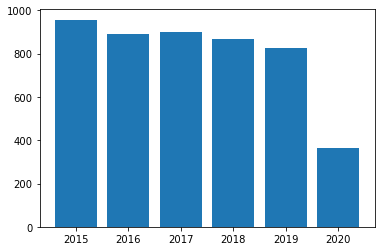

```python
plt.bar(shotsperyear['year'],shotsperyear['No of shots'])
plt.xlabel='year'
plt.ylabel='No of Shots'
```

```python
df_clean = df.dropna(subset = ['race', 'age'])
df_clean['armed'].fillna('unarmed', inplace=True)
df_clean['flee'].fillna('Not fleeing', inplace=True)
print(df_clean[df_clean['gender'].isna() == True])
df_clean = df_clean.dropna(subset = ['gender'])
df_clean.shape
```

```
Empty DataFrame
Columns: [id, name, date, manner_of_death, armed, age, gender, race, city, state, signs_of_mental_illness, threat_level, flee, body_camera, month, year]
Index: []
```

```
(4809, 16)
```

# Data Visualization

### Research Question:

"Has there been a large increase in shooting in the past 5 years?"

### Hypothesis:

The number of deaths because of shootings are influenced by the total population of the state; the more the population of the state the more the number of deaths becuase of shootings and vice verse.

### The Racial Disparity in Police Shootings

```python
print(df['race'].unique())
```

```
['A' 'W' 'H' 'B' 'O' 'N']
```

In the data, there are six different racial classifications: 'W' denotes white, 'A' denotes Asian, 'B' denotes black, 'H' denotes Hispanic, 'N' denotes Native American, and 'O' denotes others.

```python
shootings_race = df_clean[df_clean['manner_of_death'] == 'shot']
shootings_race.shape
```

```
(4564, 16)
```

```python
fig = px.histogram(shootings_race, x = 'race',
                  title = "Distribution of Police Shootings by Race")

#let's add a line to represent the number of shootings for each race if they were proportional to their population in the US
#white: 0.618, b: 0.132, h: 0.178, a: 0.053, n: 0.01, o: 0.009 These are rough estimates based on 2015 values.
races = ['A','W','H','B','N','O']
race_prop = np.array([0.053, 0.618, 0.178, 0.132, 0.01, 0.009])
fig.add_trace(go.Scatter(x = races, y = shootings_race.shape[0] * race_prop))

fig.show()
```

[interactive chart not shown]

### Visualization of police shootings by age

The total count for each race is represented by the histogram.

Then, using data from the 2015 census on actual racial distribution in the United States, I calculated how many shootings would occur if members of each race were shot in proportion to their population share. The scatter line represents this number.

```python
import plotly.figure_factory as ff
np.random.seed(1)
age_data = df_clean['age']
age_labels = ['Age']
fig = ff.create_distplot([age_data], age_labels)
fig.update_layout(title_text='Distribution of Police Shooting Victims by Age')

fig.show()
```

[interactive chart not shown]

After plotting the complete dataset's distribution. I can deduce that the majority of the victims are between the ages of 25 and 40. The right tail of the distribution is lengthy, but the left tail is substantially thicker

## States' Distribution

On the left side of the graph, I depicted the percent of total shootings in the Top 20 most trigger-happy states. The actual fraction of the overall US population represented by the state is shown on the right side. This provides with some intriguing information.

Below, the "index" column is the target varaible, and the remaining columns like "percent" and "state_prop" act as independent variables.

```python
from plotly.subplots import make_subplots

trigger_states = df_clean['state'].value_counts()[:20]
trigger_states = pd.DataFrame(trigger_states)
trigger_states = trigger_states.reset_index()
trigger_states['percent'] = trigger_states['state']*100/df_clean.shape[0]
s = [11.91, 8.74, 6.47, 2.19, 1.74, 3.2, 1.19, 3.52, 3.16, 2.29, 1.85, 2.06, 1.40, 3.86, 3.82, 1.48, 0.63, 2.03, 5.86, 2.57]
trigger_states['state_prop'] = s

fig = make_subplots(rows = 1, cols = 2, specs = [[{},{}]], shared_xaxes = True,
                  shared_yaxes = False, vertical_spacing = 1)

fig.append_trace(go.Bar(
    x = trigger_states['percent'],
    y = trigger_states['index'],
    marker = dict(
        color = 'blue',
        line = dict(
            color = 'blue',
            width = 1),
    ),
    name = 'Distribution of Shootings by State',
    orientation = 'h',
), 1, 1)

fig.append_trace(go.Bar(
    x = trigger_states['state_prop'],
    y = trigger_states['index'],
    marker = dict(
        color = 'green',
        line = dict(
            color = 'green',
            width = 1),
    ),
    name = '% of total US populaiton in the State',
    orientation = 'h',
), 1, 2)

fig.update_layout(
    title = 'Twenty US States with the most Police Shootings',
    yaxis = dict(
        showgrid = False,
        showline = False,
        showticklabels = True,
        domain = [0, 0.85],
    ),
    yaxis2 = dict(
        showgrid = False,
        showline = True,
        showticklabels = True,
        domain = [0, 0.85],
    ),
    xaxis = dict(
        zeroline = False,
        showline = False,
        showticklabels = True,
        showgrid = True,
        domain = [0, 0.42],
    ),
    xaxis2 = dict(
        zeroline = False,
        showline = False,
        showticklabels = True,
        showgrid = True,
        domain = [0.5, 0.92],
    ),
    legend = dict(x = 0.7, y = 1.038, font_size = 15),
    margin = dict(l = 100, r = 20, t = 70, b = 70),
    paper_bgcolor = 'rgb(244, 250, 277)',
    plot_bgcolor = 'rgb(244, 250, 277)',
)

fig.show()
```

[interactive chart not shown]

### Understanding from the above graph:

1. California, New Mexico, and Arizona are among the most trigger-happy states. Their share of shootings is far higher than their actual population. It's worth noting that all three of these states are located on the Mexican border. Maybe there's a connection there. We all know how conservative and trigger-happy Arizona's cops and sheriffs are. The Los Angeles Police Department (LAPD) has a similar reputation in California.
2. Surprisingly, New York performs better. Despite certain high-profile shooting cases, it generally does better in terms of percentage. It accounts for 6% of the US population but just about 2% of all shootings. This is due to the fact that the NYPD places a higher value on body cameras. Furthermore, it is a lot more liberal city in comparison. The same is true in Pennsylvania and Illinois.
3. Oklahoma is a trigger-happy state. It has a high number of police shootings while having a small population.

## Correlational Analysis

The Pearson correlation coefficient, which is a measure of the linear association between two variables, is one technique to evaluate the relationship between the year and the number of shots. It always takes on a value between -1 and 1, with the following values:

1. A totally negative linear correlation is shown by a value of -1.
2. A value of 0 shows that there is no linear relationship.
3. A complete positive linear correlation is indicated by a value of 1.

I used the Numpy corrcoef() function to calculate the correlatoin between the year and the number of shots. The stronger the association between the two variables, the further the correlation coefficient is from zero.

```python
import numpy as np
shots=df['year'].value_counts()
shotsperyear =shots.to_frame()
shotsperyear.reset_index(level=0, inplace=True)
shotsperyear.columns=['year','No of shots']
np.corrcoef(shotsperyear['year'],shotsperyear['No of shots'])[0,1]
```

```
-0.7802020238351912
```

The correlation coefficient is -0.780, which is a nagtive correlation.

## Correlation table

```python
corr = df.corr()
corr.style.background_gradient(cmap='coolwarm')
```

|  | id | age | signs_of_mental_illness | body_camera | month | year |
| --- | --- | --- | --- | --- | --- | --- |
| id | 1.000000 | 0.022170 | -0.086693 | 0.031106 | 0.048883 | 0.982367 |
| age | 0.022170 | 1.000000 | 0.098206 | -0.035648 | -0.001718 | 0.020911 |
| signs_of_mental_illness | -0.086693 | 0.098206 | 1.000000 | 0.047359 | -0.027632 | -0.081322 |
| body_camera | 0.031106 | -0.035648 | 0.047359 | 1.000000 | 0.009541 | 0.030510 |
| month | 0.048883 | -0.001718 | -0.027632 | 0.009541 | 1.000000 | -0.127932 |
| year | 0.982367 | 0.020911 | -0.081322 | 0.030510 | -0.127932 | 1.000000 |

## Now, let's take a look at the overall trend.

```python
years = df_clean[['year','race']]
years['shootings'] = 1
years = years.groupby(['year','race']).sum()
years = years.reset_index()
fig = px.bar(years , y = 'shootings', x = 'year',color = 'race', barmode = 'group', title = 'Shootings from 2015-2020',
            color_discrete_sequence = px.colors.qualitative.D3)
fig.show()
```

[interactive chart not shown]

### References:

```
https://www.kaggle.com/code/anjalirani/a-short-analysis-on-police-shootings
https://www.kaggle.com/code/shoaibmnagi/us-police-and-racism-analyzing-shooting-data
```